# DataAnalysis

Eric Massa

1/23/2020

## R Markdown

R Markdown document “DataGeneration.Rmd” for BIOL 812 week 3 assignment. Each step is labelled with comments in the code below. Additional commentary is found below as needed.

Steps were as follows:

1. Read measurements.csv into an object in R called MData
2. Include functions from the Data Science Tutorial to do each of the following:
- Change the column names to shorter, 3-letter abbreviations
- Add a new data column called Volume that calculates limb volume (Hint: pay careful attention to your units – assume unitsW shows the units for Limb.Width and unitsL shows the units for Limb.Length). Treat these as limb dimensions (e.g. arms, legs, fins).
- Group the species into 2 or more imaginary groups (you decide on the category names) and add a column denoting these groups
- Summarize the mean and SD of Length, Width and Volume for each of your artificial groups, and present in table form.
- Plot Width and Length, as in Part III from last week’s assignment BUT embed the graph in your R markdown file rather than creating a separate pdf.
- Plot Width and Length, but only for species that have above-average volume
- Add a table showing only Species and Volume for only the species with below-average volume
3. Add notes to your ‘official’ report.
4. Knit your Rmd file to a html format.
5. Save and upload your files to the corresponding GitHub repository (hint: review ‘commit’, ‘push’ and ‘pull’)
6. Submit a link to your GitHub repository to OnQ

```r
#Necessary libraries
library(dplyr)
```

```r
library(ggplot2)
```

##Read data

```r
#Part 2, step 1
MData <- read.csv("measurements.csv")
```

##Rename dataframe columns

```r
#Part 2, step 2, bullet 1
MData2 <- rename(.data = MData, SPP = Species, LWD = Limb.Width, LLG = Limb.Length, UNW = unitsW, UNL = unitsL)
```

##Calculate limb volume First convert all limb dimensions into cm. Second, calculate limb volume in cm^3

```r
#Part 2, step 2, bullet 2
cmL <- numeric()
cmW <- numeric()
for (i in 1:nrow(MData2)) {
  if (MData2$UNL[i] == "mm") {
    cmL[i] <- MData2$LLG[i]/10
  } else {
    cmL[i] <- MData2$LLG[i]
  }
}
for (i in 1:nrow(MData2)) {
  if (MData2$UNW[i] == "mm") {
    cmW[i] <- MData2$LWD[i]/10
  } else {
    cmW[i] <- MData2$LWD[i]
  }
}
vol <- numeric()
for (i in 1:10) {
  vol[i] <- pi * cmW[i]^2 * cmL[i]
}
```

append volume data to imported dataset.

```r
MData3 <- mutate(MData2, Volume = vol)
```

## Data grouping and summary

```r
#Part 2, step 2, bullet 3
MData4 <- mutate(MData3, Group = c(rep("A",5), rep("B",5)))
#Part 2, step 2, bullet 4
summarize(.data = group_by(MData4, Group), MeanL = mean(cmL), SDL = sd(cmL), MeanW = mean(cmW), SDW = sd(cmW), MeanV = mean(Volume), SDV = sd(Volume))
```

```
## # A tibble: 2 x 7
##   Group MeanL   SDL MeanW   SDW   MeanV     SDV
##   <chr> <dbl> <dbl> <dbl> <dbl>   <dbl>   <dbl>
## 1 A      65.8  97.1  11.2  12.7  12337.  23479.
## 2 B      65.8  97.1  11.2  12.7 131840. 285719.
```

##Plots Plots demonstrating relationships in the data. The first plot demonstrates the relationship between limb length and limb width of all organisms in the data.

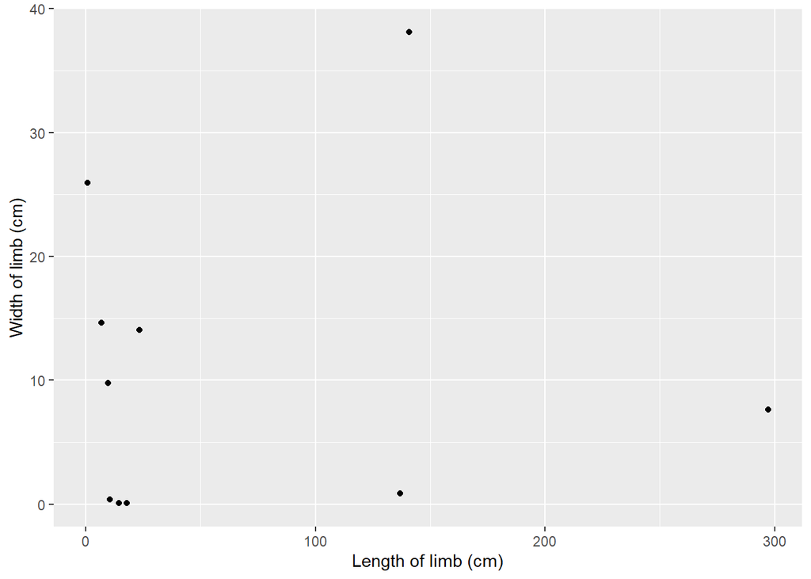

```r
#Part 2, step 2, bullet 5
qplot(x = cmL, y = cmW, xlab = "Length of limb (cm)", ylab = "Width of limb (cm)")
```

The second plot demonstrates the same, but only for those species with limb volumes above average.

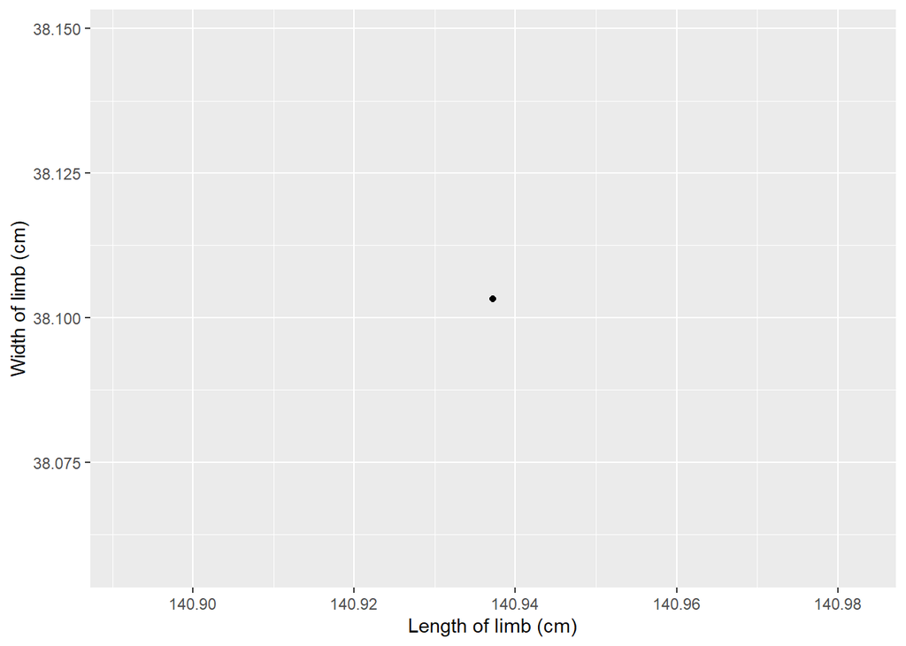

```r
#Part 2, step 2, bullet 6
qplot(x = cmL[MData4$Volume > mean(MData4$Volume)], y = cmW[MData4$Volume > mean(MData4$Volume)], xlab = "Length of limb (cm)", ylab = "Width of limb (cm)")
```

Show species name and limb volume for species with below-average limb volume.

```r
#Part 2, step 2, bullet 7
filter(.data = MData4[,c(1,6)], Volume < mean(MData4$Volume))
```

```
##                SPP       Volume
## 1 Ursus americanus 4.598088e+03
## 2     Ursus arctos 2.892206e+03
## 3    Ursus ursinus 4.823609e+00
## 4  Ursus maritimus 5.419096e+04
## 5  Ursus malayanus 4.114579e-01
## 6 Ursus thibetanus 3.167581e+02
## 7   Ursus etruscus 1.449891e+04
## 8    Ursus minimus 2.164249e-01
## 9   Ursus rossicus 1.547867e+03
```

```r
#Part 2, step 3
#...

#Part 2, step 4
#Knit to file, no code.
#Part 2, step 5
#Saving and uploading files to GitHub repository. No code.
#Part 2, step 6
#Submit to OnQ. No code.
```